# Acute Stroke Paper Supplemental Results

Eckhard Schlemm

# Results

## Missing data

| ID | 3-5d NIHSS | 3-5d rGS | 3-5d FM | 1m NIHSS | 1m rGS | 1m FM | 3m NIHSS | 3m rGS | 3m FM | 12m NIHSS | 12m rGS | 12m FM |
| --- | --- | --- | --- | --- | --- | --- | --- | --- | --- | --- | --- | --- |
| 3 | ● |  | ● | ● |  | ● | ● |  | ● | ● |  | ● |
| 5 |  |  |  | ● | ● | ● | ● |  | ● | ● |  | ● |
| 7 | ● | ● | ● | ● | ● | ● | ● | ● | ● | ● | ● | ● |
| 9 | ● |  | ● | ● | ● | ● | ● | ● | ● | ● | ● | ● |
| 12 | ● | ● | ● | ● | ● | ● | ● | ● | ● | ● | ● | ● |
| 13 | ● | ● | ● | ● | ● | ● | ● | ● | ● | ● | ● | ● |
| 14 | ● | ● | ● | ● | ● | ● | ● | ● | ● | ● | ● | ● |
| 15 | ● | ● | ● | ● | ● | ● | ● | ● | ● | ● | ● | ● |
| 16 | ● | ● | ● | ● | ● | ● | ● | ● | ● | ● | ● | ● |
| 20 | ● |  | ● | ● | ● | ● | ● | ● | ● | ● |  | ● |
| 22 | ● | ● | ● | ● | ● | ● | ● | ● | ● | ● | ● | ● |
| 23 | ● | ● | ● | ● | ● | ● | ● | ● |  |  |  |  |
| 24 | ● | ● | ● | ● | ● | ● | ● | ● | ● | ● | ● | ● |
| 25 | ● | ● | ● | ● | ● | ● | ● | ● | ● | ● | ● | ● |
| 26 | ● | ● | ● | ● | ● | ● | ● | ● | ● | ● | ● | ● |
| 30 | ● | ● | ● | ● | ● | ● | ● | ● | ● | ● | ● | ● |
| 32 | ● | ● | ● | ● | ● | ● | ● | ● | ● | ● | ● | ● |
| 33 | ● | ● | ● | ● | ● | ● | ● | ● | ● | ● | ● | ● |
| 35 | ● | ● | ● | ● | ● | ● | ● | ● | ● | ● | ● | ● |
| 36 | ● | ● | ● | ● | ● | ● | ● | ● | ● | ● | ● | ● |
| 43 | ● | ● | ● | ● | ● | ● | ● | ● | ● | ● | ● | ● |
| 44 | ● | ● | ● | ● | ● | ● | ● | ● | ● | ● | ● | ● |
| 45 | ● | ● | ● | ● | ● | ● | ● | ● | ● | ● | ● | ● |
| 46 | ● | ● | ● | ● | ● | ● | ● | ● | ● | ● | ● | ● |
| 47 | ● | ● | ● | ● | ● | ● | ● | ● | ● | ● | ● | ● |
| 51 | ● | ● | ● | ● | ● | ● | ● | ● | ● | ● | ● | ● |
| 52 | ● | ● | ● | ● | ● | ● | ● | ● | ● | ● | ● | ● |
| 53 | ● | ● | ● | ● | ● | ● | ● | ● | ● |  |  |  |
| 54 | ● | ● | ● | ● | ● | ● | ● | ● | ● | ● | ● | ● |
| 55 | ● |  | ● | ● | ● | ● | ● | ● | ● | ● | ● | ● |

S-Tab. 1: Details of available clinical data by subject, timepoint and testing modality. Complete records are indicated by a green background. NIHSS = National Institutes of Health Stroke Scale, rGS = relative grip strength, FM = Fugl-Meyer, d = days, m = months.

## Numerical connectivity

Global structural connectivity, quantified by the median edge weight, was shown to decrease non-linearly over time with a disassociation between stroke and intact hemispheres. S-Tab. 2 reports statistical details of the exponential models fit to intrahemispheric connectivity both jointly and separately.

|  |  | joint model estimate | joint model s.e. | joint model p | ipsilesional estimate | ipsilesional s.e. | ipsilesional p | contralesional estimate | contralesional s.e. | contralesional p |
| --- | --- | --- | --- | --- | --- | --- | --- | --- | --- | --- |
| q50 | a | 0.472200 | 0.005396 | 2.94e-157 | 0.47130 | 0.005842 | 3.79e-79 | 0.473000 | 0.006285 | 9.76e-77 |
|  | b | 1.015000 | 1.394000 | 0.4674 | 1.01000 | 1.242000 | 0.4186 | 1.019000 | 3.014000 | 0.7361 |
|  | Δ | -0.002658 | 0.003910 | 0.4975 | -0.00758 | 0.003679 | 0.0426 | -0.003838 | 0.004471 | 0.3932 |
|  | Δ~ipsi~ | -0.006037 | 0.003783 | 0.1122 | NA | NA |  | NA | NA |  |

S-Tab. 2: Point estimates, standard errors, and p-values of model parameters obtained from fitting the exponential model (1) to temporal profiles of intrahemispheric median connectivity $q_{50}$. In the joint model, the parameter of topological change, Δ, was allowed to vary between stroke and intact hemispheres. Standard errors and $p$-values result from non-linear mixed-effects regressions fit either jointly (‘joint model’) or separately for stroke (‘ipsilesional’) and intact (‘contralesional’) hemispheres, using the R package nlme. q50 = median connectivity, s.e. = standard error.

## Sensitivity analyses for the effect of network density

### Effects of time and lesion status on global graph parameters

Differences in the time course of GGPs between ipsi- and contralesional hemispheres were assessed by allowing different values of $\Delta$ in the two groups. Results are displayed visually in S-Fig. 1.

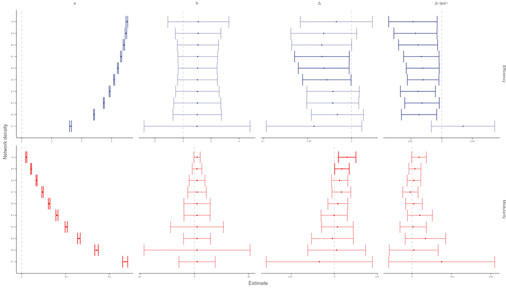

S-Fig. 1: Results of non-linear mixed-effects regression modelling of global graph parameters jointly in stroke and intact hemispheres for different network densities. Dots indicate point estimates, bars 95% confidence intervals. Solid lines indicate intervals not containing zero.

The dependence of the global graph metrics on network density is reflected in the intercept model parameter $a$ which indicates a rapid decline of efficiency and a marked increase in modularity in very sparse networks. An excess decline in ipsilesional efficiency, as measured by Δ<sub>ipsi</sub> is statistically significant at all but the smallest thresholds. There is no significant difference in the increase in modularity at any threshold. The nuisance parameter $b$ quantifying the rate of change over time is numerically stable across thresholds and not significantly different from zero for all considered GGPs.

The time course of GGPs was also quantified and analysed in stroke and intact hemispheres separately (S-Fig. 2).

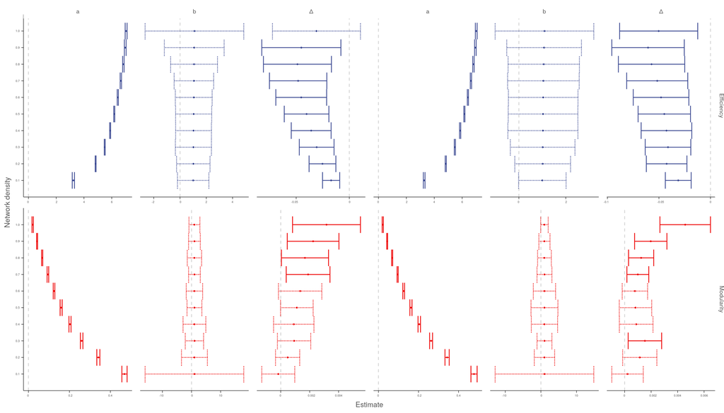

S-Fig. 2: Results of non-linear mixed-effects regression modelling of global graph parameters separately in stroke and intact hemispheres for different network densities. Dots indicate point estimates, bars 95% confidence intervals. Solid lines indicate intervals not containing zero.

### Effects of lesion volume on global network change

In the main text it is shown that lesion volume modulates the change in global network architecture over time in stroke but not intact hemispheres. S-Fig. 3 reports a sensitivity analysis for the influence of network density on this effect.

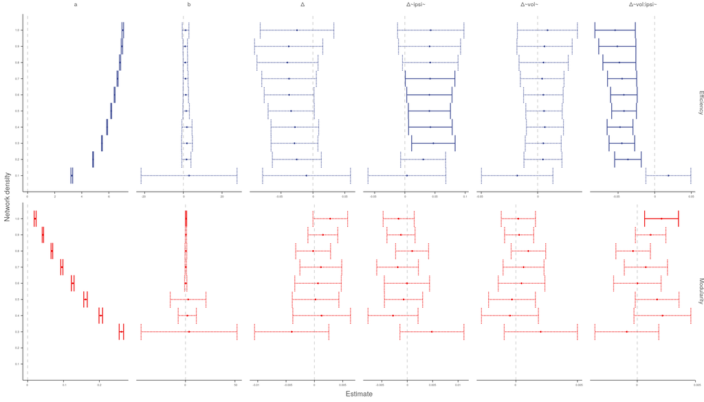

S-Fig. 3: Results of non-linear mixed-effects regressions modelling the effect of lesion volume on change of global graph parameters jointly in stroke and intact hemispheres for different network densities. Dots indicate point estimates, bars 95% confidence intervals. Solid lines indicate intervals not containing zero.

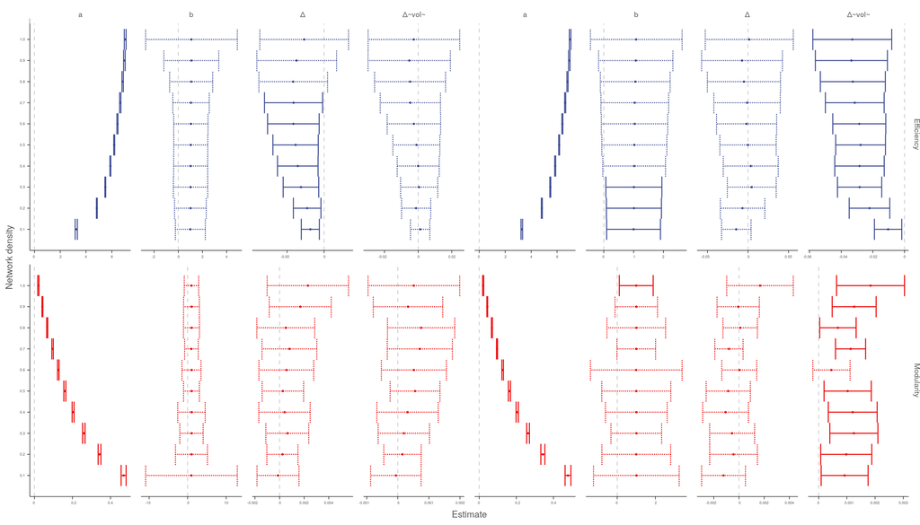

S-Fig. 4: Results of non-linear mixed-effects regressions modelling the effect of lesion volume on change of global graph parameters separately in stroke and intact hemispheres for different network densities. Dots indicate point estimates, bars 95% confidence intervals. Solid lines indicate intervals not containing zero.

Consistent with the joint analysis, there is a significant effect of lesion volume on topological network change in ipsilesional hemispheres across network densities. There is no significant effect of lesion volume on topological network change in contralesional hemispheres at any network density.

## Local graph parameters

### Local network changes

Non-linear mixed effects modelling with an exponential effect of time revealed significant differences in the time course of local graph parameters between ipsi- and contralesional hemispheres in a total of 7 brain regions, see S-Tab. 4. The lentiform nucleus was excluded from the mass-univariate analysis because it was contained in or had significant overlap with a majority of the ischemic lesions. Local network architecture was disrupted in the acute stage, as indicated by a significant effect of lesion status on the model parameter $a$, in the pre- and postcentral, lateralorbitofrontal and inferior frontal (partes orbitalis and triangularis) gyri. Excess ipsilesional change of local network integrity over the study period (model parameter Δ) was localised in this joint analysis to the rostral and caudal anterior cingulate cortices. Focusing on stroke hemispheres alone, significant decline in ipsilesional local network measures over time was detected in more widespread brain areas, including regions of frontal, temporal and parietal lobes as well as the thalamus (S-Tab. 5).

|  |  | parameter | point estimate | standard error | p |
| --- | --- | --- | --- | --- | --- |
| caudalanteriorcingulate | strength | a~relpos~ | -0.592539066 | 1.75748794 | 0.7364 |
|  | strength | Δ~relpos~ | 4.331378059 | 2.09340854 | 0.0399 |
| lateralorbitofrontal | clustering | a~relpos~ | 0.082210828 | 0.04030918 | 0.0428 |
|  | clustering | Δ~relpos~ | 0.028359294 | 0.05263922 | 0.5907 |
|  | efficiency | a~relpos~ | 0.094973063 | 0.03210379 | 0.0035 |
|  | efficiency | Δ~relpos~ | -0.008619835 | 0.04236758 | 0.8390 |
|  | strength | a~relpos~ | 4.441630251 | 1.37665621 | 0.0015 |
|  | strength | Δ~relpos~ | -1.267452680 | 8.77063263 | 0.8852 |
| parsorbitalis | clustering | a~relpos~ | 0.098567320 | 0.03828440 | 0.0108 |
|  | clustering | Δ~relpos~ | 0.011054770 | 0.05035417 | 0.8265 |
|  | efficiency | a~relpos~ | 0.104246389 | 0.03709726 | 0.0055 |
|  | efficiency | Δ~relpos~ | -0.008898291 | 0.04879848 | 0.8555 |
| parstriangularis | clustering | a~relpos~ | 0.081543092 | 0.03940246 | 0.0398 |
|  | clustering | Δ~relpos~ | 0.010537405 | 0.05119998 | 0.8372 |
|  | efficiency | a~relpos~ | 0.076894344 | 0.03265695 | 0.0196 |
|  | efficiency | Δ~relpos~ | -0.002208266 | 0.04253716 | 0.9587 |
| postcentral | efficiency | a~relpos~ | 0.074277383 | 0.03157865 | 0.0197 |
|  | efficiency | Δ~relpos~ | 0.031600849 | 0.04092876 | 0.4410 |
|  | strength | a~relpos~ | 4.009874188 | 1.80595869 | 0.0276 |
|  | strength | Δ~relpos~ | 1.096165108 | 2.16004197 | 0.6124 |
| precentral | efficiency | a~relpos~ | 0.070488116 | 0.03157192 | 0.0267 |
|  | efficiency | Δ~relpos~ | 0.044735210 | 0.04083252 | 0.2746 |
| rostralanteriorcingulate | clustering | a~relpos~ | -0.057284743 | 0.04456747 | 0.2002 |
|  | clustering | Δ~relpos~ | 0.124857279 | 0.05639781 | 0.0280 |
|  | efficiency | a~relpos~ | -0.049820645 | 0.04074181 | 0.2229 |
|  | efficiency | Δ~relpos~ | 0.103065027 | 0.05162473 | 0.0473 |
|  | strength | a~relpos~ | -4.084118551 | 2.34811802 | 0.0836 |
|  | strength | Δ~relpos~ | 7.656244907 | 2.81993341 | 0.0072 |

S-Tab. 4: Point estimates, standard errors, and p-values of model parameters obtained from fitting the exponential model (1) to temporal profiles of local graph measures in individual ROIs. The intercept $a$ and total change Δ were allowed to vary between stroke and intact hemispheres. Standard errors and $p$-values result from non-linear mixed-effects regressions fit jointly for stroke and intact hemispheres using the R package nlme. ROIs with a comparable temporal profile of all three local graph measures ipsi- and contralesionally are not shown.

|  |  | point estimate Δ | standard error | p |
| --- | --- | --- | --- | --- |
| thalamus | strength | -2.87486799 | 0.70734377 | 0.0001 |
|  | efficiency | -0.06347416 | 0.01847349 | 0.0009 |
|  | clustering | -0.09308385 | 0.02774760 | 0.0012 |
| superiorfrontal | strength | -3.30810978 | 0.84892581 | 0.0002 |
|  | efficiency | -0.05393296 | 0.01947541 | 0.0070 |
|  | clustering | -0.06674866 | 0.02795765 | 0.0193 |
| rostralanteriorcingulate | strength | -6.30104102 | 1.77889554 | 0.0007 |
|  | efficiency | -0.08227798 | 0.03181673 | 0.0115 |
|  | clustering | -0.09377918 | 0.03381435 | 0.0069 |
| caudalanteriorcingulate | strength | -4.42054834 | 1.27499143 | 0.0008 |
|  | efficiency | -0.08290236 | 0.02754337 | 0.0035 |
|  | clustering | -0.10225808 | 0.03355013 | 0.0031 |
| parsopercularis | strength | -5.33234229 | 1.75425501 | 0.0032 |
| postcentral | efficiency | -0.04618244 | 0.02145629 | 0.0343 |
|  | clustering | -0.06964767 | 0.02434808 | 0.0054 |
| bankssts | efficiency | -0.04006139 | 0.01861171 | 0.0343 |
|  | clustering | -0.05722623 | 0.02032539 | 0.0061 |
| parsorbitalis | strength | -4.96067160 | 1.80019362 | 0.0072 |
| precentral | strength | -2.75751317 | 1.18422263 | 0.0224 |
|  | efficiency | -0.05008565 | 0.02137751 | 0.0216 |
|  | clustering | -0.06907862 | 0.02584309 | 0.0091 |
| middletemporal | efficiency | -0.04906269 | 0.02320784 | 0.0376 |
|  | clustering | -0.07772683 | 0.03002335 | 0.0114 |
| temporalpole | strength | -5.49496144 | 2.14500621 | 0.0123 |
|  | efficiency | -0.07751676 | 0.03724841 | 0.0406 |
|  | clustering | -0.09439017 | 0.04162120 | 0.0260 |
| parstriangularis | efficiency | -0.05649617 | 0.02531337 | 0.0284 |
|  | clustering | -0.07922182 | 0.03101382 | 0.0125 |
| pericalcarine | strength | -7.13883187 | 2.83349495 | 0.0137 |
| posteriorcingulate | efficiency | -0.05646861 | 0.02595115 | 0.0325 |
|  | clustering | -0.08284335 | 0.03376272 | 0.0163 |
| paracentral | efficiency | -0.05569774 | 0.02726803 | 0.0443 |
|  | clustering | -0.07790294 | 0.03229983 | 0.0181 |
| supramarginal | clustering | -0.06306242 | 0.02768616 | 0.0254 |
| insula | clustering | -0.06244341 | 0.02823550 | 0.0298 |
| superiorparietal | clustering | -0.05724899 | 0.02640792 | 0.0331 |
| cuneus | clustering | -0.07132348 | 0.03372396 | 0.0375 |
| superiortemporal | clustering | -0.06237749 | 0.02990074 | 0.0401 |

S-Tab. 5: Point estimates, standard errors and p-values of model parameter Δ obtained from fitting the exponential model (1) to temporal profiles of ipsilesional local graph measures in individual ROIs. Standard errors and $p$-values result from non-linear mixed-effects regressions fit using the R package nlme. ROIs without significant change over time in any of the three local graph parameters are not shown.

### Association between lesion volume and local network change.

|  |  | point estimate of Δ~vol:ipsi~ | standard error | p |
| --- | --- | --- | --- | --- |
| caudalanteriorcingulate | clustering | 0.05918989 | 0.01952920 | 0.0028 |
|  | efficiency | 0.04269834 | 0.01627408 | 0.0094 |
| parsopercularis | clustering | 0.08086459 | 0.01676055 | 2.91e-06 |
| parsorbitalis |  | 0.03819923 | 0.01739935 | 0.0294 |
| postcentral |  | 0.10296453 | 0.01595128 | 9.15e-10 |
| precentral |  | 0.10008843 | 0.01602294 | 2.79e-09 |
|  | strength | 3.49822665 | 0.70403057 | 1.52e-06 |
| rostralanteriorcingulate | clustering | 0.07766328 | 0.03224724 | 0.0170 |
| superiorfrontal |  | 0.06378442 | 0.01882458 | 0.0009 |
|  | efficiency | 0.04720011 | 0.01371100 | 0.0007 |
|  | strength | 1.56457303 | 0.74013146 | 0.0359 |
| thalamus | clustering | 0.06892981 | 0.02144211 | 0.0015 |
|  | efficiency | 0.04767449 | 0.01436686 | 0.0011 |
|  | strength | 1.23597481 | 0.62293420 | 0.0487 |

S-Tab. 6: Model parameter Δ<sub>vol:ipsi</sub> (point estimates, standard errors, p-values) obtained from fitting the exponential model (1) to temporal profiles of local graph measures in individual ROIs. Total change $\Delta$ is modelled as a linear function of log lesion volume, both intercept and slope are allowed to vary between stroke und intact hemispheres. Standard errors and $p$-values result from non-linear mixed-effects regressions fit jointly for stroke and intact hemispheres using the R package nlme. $p$-values in bold remain significant at a Bonferroni level of $0.05/36$. ROIs without a significant difference of the modulatory effect of lesion volume on local network change between stroke and intact hemispheres are not shown.

|  |  | point estimate of Δ~vol~ | standard error | p |
| --- | --- | --- | --- | --- |
| caudalanteriorcingulate | clustering | -0.07593381 | 0.01987423 | 0.0003 |
|  | efficiency | -0.06387637 | 0.01631250 | 0.0002 |
|  | strength | -2.48320517 | 0.82418061 | 0.0035 |
| postcentral | clustering | -0.06740521 | 0.01539099 | 3.66e-05 |
|  | efficiency | -0.05893131 | 0.01266550 | 1.32e-05 |
| precentral | clustering | -0.06410077 | 0.01591064 | 0.0001 |
|  | efficiency | -0.05799585 | 0.01258295 | 1.55e-05 |
|  | strength | -3.17403407 | 0.68107506 | 1.28e-05 |
| superiorfrontal | clustering | -0.05838319 | 0.01731666 | 0.0012 |
|  | efficiency | -0.04196056 | 0.01216708 | 0.0009 |
| thalamus | clustering | -0.05220706 | 0.01856559 | 0.0062 |
|  | efficiency | -0.04184874 | 0.01173298 | 0.0006 |
|  | strength | -1.55368266 | 0.45271453 | 0.0010 |

S-Tab. 7: Model parameter Δ<sub>vol</sub> (point estimates, standard errors, p-values) obtained from fitting the exponential model (1) to temporal profiles of local graph measures in individual ipsilesional ROIs. Total change $\Delta$ is modelled as a linear function of log lesion volume. Standard errors and $p$-values result from non-linear mixed-effects regressions fit using the R package nlme. p$-values in bold remain significant at a Bonferroni level of $0.05/36$. ROIs without a significant effect of lesion volume on local network change are not shown.

# Associations between clinical outcome and network change.

## Global graph measures

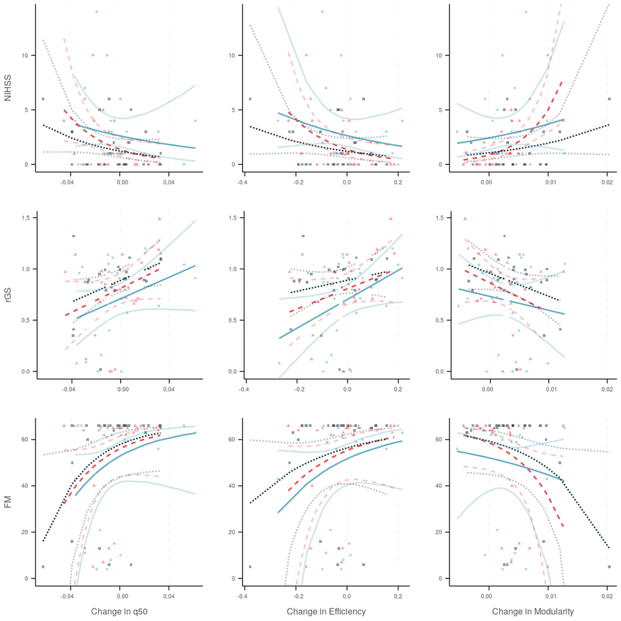

In S-Tab. 8 we report details about the statistical analysis of the relationhip between change in global topology and clinical outcome without including lesion volume as a nuisance regressor.

|  |  | pooled model estimate | pooled model s.e. | pooled model p | 1m estimate | 1m s.e. | 1m p | 3m estimate | 3m s.e. | 3m p | 12m estimate | 12m s.e. | 12m p |
| --- | --- | --- | --- | --- | --- | --- | --- | --- | --- | --- | --- | --- | --- |
| NIHSS | Efficiency | -5.163149 | 1.8094885 | 0.0056 | -3.572013 | 2.5907572 | 0.1802 | -4.1973720 | 3.1386647 | 0.1942 | -3.2839623 | 2.8285165 | 0.2575 |
|  | Modularity | 159.683139 | 50.4256337 | 0.0022 | 42.265161 | 69.3088542 | 0.5475 | 140.8971911 | 71.2689635 | 0.0602 | 101.7051558 | 56.1452832 | 0.0831 |
|  | q50 | -26.554851 | 8.9975070 | 0.0042 | -22.998142 | 15.0478383 | 0.1390 | -26.7707253 | 16.4527053 | 0.1173 | -29.0000266 | 15.1646835 | 0.0684 |
| rGS | Efficiency | 1.446398 | 0.5646062 | 0.0126 | -2.157503 | 2.1734282 | 0.3304 | -5.4314768 | 2.1687554 | 0.0198 | -2.7949775 | 2.1434103 | 0.2051 |
|  | Modularity | -39.435708 | 17.3870779 | 0.0265 | 41.804863 | 56.7620258 | 0.4683 | 174.6037285 | 44.6421524 | 0.0007 | 60.2457566 | 46.9743290 | 0.2124 |
|  | q50 | 8.631756 | 2.4163906 | 0.0007 | -9.160331 | 11.3160975 | 0.4259 | -28.2313944 | 12.0497786 | 0.0282 | -17.3411340 | 11.2493885 | 0.1368 |
| FM | Efficiency | -5.978118 | 2.3728553 | 0.0139 | 1.410780 | 0.6844899 | 0.0503 | 0.9902475 | 0.7031543 | 0.1737 | 0.5387956 | 0.5624157 | 0.3495 |
|  | Modularity | 191.073999 | 65.2556617 | 0.0045 | -13.487741 | 19.5600360 | 0.4971 | -28.2970083 | 20.3081611 | 0.1781 | -22.2127660 | 13.7492152 | 0.1219 |
|  | q50 | -41.459830 | 11.8105249 | 0.0008 | 5.247708 | 3.2987173 | 0.1247 | 5.8270008 | 3.6029672 | 0.1207 | 5.2350882 | 2.6130724 | 0.0589 |

S-Tab. 8: Regression coefficients (point estimates, standard errors and p-values) on the link scale between change in global network measures and clinical outcome. In the case of FM and NIHSS scores, quasi-Poisson regressions with a $\log$-link are used; in the case of relative grip strength a Gaussian regression with identity link is used. The first three columns represent pooled estimates from joint two-stage regressions across the subacute and chronic stages. NIHSS = National Institutes of Health Stroke Scale, rGS = relative grips strength, FM = Fugl-Meyer, q50 = median connectivity, s.e. = standard error.

## Local graph measures

|  |  | NIHSS estimate | NIHSS s.e. | NIHSS p | FM estimate | FM s.e. | FM p | rGS estimate | rGS s.e. | rGS p |  |  |  |
| --- | --- | --- | --- | --- | --- | --- | --- | --- | --- | --- | --- | --- | --- |
| bankssts | clustering | -5.13701310 | 1.91773144 | 0.0091 | NA | NA |  | NA | NA |  |  |  |  |
| parsopercularis |  | NA | NA |  |  |  |  | 1.09543457 | 0.275949027 | 0.0002 |  |  |  |
|  |  |  |  |  | -2.56166864 | 1.17151432 | 0.0319 | NA | NA |  |  |  |  |
|  | efficiency |  |  |  | NA | NA |  | 1.14946504 | 0.284212485 | 0.0001 |  |  |  |
|  | strength |  |  |  |  |  |  | 0.01579055 | 0.004018643 | 0.0002 |  |  |  |
|  |  | -0.02804007 | 0.01168631 | 0.0189 |  |  |  | NA | NA |  |  |  |  |
| postcentral | clustering | NA | NA |  |  |  |  | 1.05826506 | 0.294963968 | 0.0006 |  |  |  |
|  |  | -3.34356719 | 0.99651656 | 0.0012 |  |  |  | NA | NA |  |  |  |  |
|  |  | NA | NA |  | -4.86437359 | 1.19572176 | 0.0001 |  |  |  |  |  |  |
|  | efficiency |  |  |  | NA | NA |  |  |  |  | 1.04628778 | 0.330159375 | 0.0023 |
|  |  | -3.08197569 | 1.11809919 | 0.0073 |  |  |  | NA | NA |  |  |  |  |
|  |  | NA | NA |  | -4.32663799 | 1.29708764 | 0.0013 |  |  |  |  |  |  |
| precentral | clustering |  |  |  | NA | NA |  |  |  |  | 0.96275691 | 0.410152260 | 0.0218 |
|  | efficiency |  |  |  |  |  |  | 1.00027515 | 0.405411694 | 0.0161 |  |  |  |
|  | strength |  |  |  |  |  |  | 0.01876874 | 0.006688257 | 0.0065 |  |  |  |
|  |  | -0.05254576 | 0.02116336 | 0.0153 |  |  |  | NA | NA |  |  |  |  |
| rostralanteriorcingulate |  | NA | NA |  |  |  |  | -0.01502608 | 0.006165756 | 0.0174 |  |  |  |
|  |  | 0.05590757 | 0.02371533 | 0.0210 |  |  |  | NA | NA |  |  |  |  |
|  |  | NA | NA |  | 0.06255694 | 0.02943709 | 0.0369 |  |  |  |  |  |  |
| superiorfrontal | clustering |  |  |  | NA | NA |  |  |  |  | 1.05818859 | 0.423298572 | 0.0148 |
|  |  | -4.02415945 | 1.39100751 | 0.0050 |  |  |  | NA | NA |  |  |  |  |
|  |  | NA | NA |  | -4.82074015 | 1.85137317 | 0.0111 |  |  |  |  |  |  |
|  | efficiency |  |  |  | NA | NA |  |  |  |  | 1.00484438 | 0.503216346 | 0.0498 |
|  |  | -3.63227297 | 1.76306136 | 0.0428 |  |  |  | NA | NA |  |  |  |  |
| thalamus | clustering | NA | NA |  |  |  |  | 1.23712191 | 0.331607951 | 0.0004 |  |  |  |
|  |  | -4.09024085 | 1.09247976 | 0.0004 |  |  |  | NA | NA |  |  |  |  |
|  |  | NA | NA |  | -6.15059227 | 1.39822839 | 3.54e-05 |  |  |  |  |  |  |
|  | efficiency |  |  |  | NA | NA |  |  |  |  | 1.35976338 | 0.378042368 | 0.0006 |
|  |  | -4.26355412 | 1.37888244 | 0.0028 |  |  |  | NA | NA |  |  |  |  |
|  |  | NA | NA |  | -7.17483084 | 1.64627902 | 4.11e-05 |  |  |  |  |  |  |
|  | strength |  |  |  | NA | NA |  |  |  |  | 0.03523679 | 0.009878338 | 0.0007 |
|  |  | -0.09772629 | 0.03263501 | 0.0037 |  |  |  | NA | NA |  |  |  |  |
|  |  | NA | NA |  | -0.16017714 | 0.03515352 | 1.98e-05 |  |  |  |  |  |  |

S-Tab. 9: Regression coefficients (point estimates, standard errors, and p-values) on the link scale between change in local network measures and clinical outcome from joint two-stage regressions across subacute and chronic stages. In the case of FM and NIHSS scores, quasi-Poisson regressions with a $\log$-link are used; in the case of relative grip strength a Gaussian regression with identity link is used. ROIs without a significant association between network change and clinical outcome are not shown. NIHSS = National Institutes of Health Stroke Scale, rGS = relative grips strength, FM = Fugl-Meyer, q50 = median connectivity, s.e. = standard error, d = days, m = months.

|  |  | NIHSS estimate | NIHSS s.e. | NIHSS p | FM estimate | FM s.e. | FM p | rGS estimate | rGS s.e. | rGS p |  |  |  |  |  |  |
| --- | --- | --- | --- | --- | --- | --- | --- | --- | --- | --- | --- | --- | --- | --- | --- | --- |
| caudalanteriorcingulate | strength | NA | NA |  | NA | NA |  | -0.01981128 | 0.006808718 | 0.0049 |  |  |  |  |  |  |
| parsopercularis | clustering |  |  |  |  |  |  | 0.79468265 | 0.323647239 | 0.0166 |  |  |  |  |  |  |
|  | efficiency |  |  |  |  |  |  | 0.84212879 | 0.343320995 | 0.0167 |  |  |  |  |  |  |
|  | strength |  |  |  |  |  |  | 0.01143237 | 0.004626591 | 0.0160 |  |  |  |  |  |  |
| postcentral | clustering |  |  |  |  |  |  | 0.73690453 | 0.324370092 | 0.0263 |  |  |  |  |  |  |
|  |  | -2.48717916 | 1.13540836 | 0.0316 |  |  |  | NA | NA |  |  |  |  |  |  |  |
|  |  | NA | NA |  | -4.09877340 | 1.37174696 | 0.0038 |  |  |  |  |  |  |  |  |  |
|  | efficiency |  |  |  | -3.20677264 | 1.52733426 | 0.0392 |  |  |  |  |  |  |  |  |  |
| rostralanteriorcingulate | strength |  |  |  | NA | NA |  |  |  |  | -0.01353244 | 0.005753353 | 0.0216 |  |  |  |
|  |  | 0.05075427 | 0.02267517 | 0.0282 |  |  |  |  |  |  | NA | NA |  |  |  |  |
|  |  | NA | NA |  | 0.05589005 | 0.02777974 | 0.0479 |  |  |  |  |  |  |  |  |  |
| thalamus | clustering |  |  |  | NA | NA |  | 0.87382192 | 0.371544933 | 0.0216 |  |  |  |  |  |  |
|  |  | -3.22526046 | 1.27942557 | 0.0139 |  |  |  | NA | NA |  |  |  |  |  |  |  |
|  |  | NA | NA |  | -5.58899965 | 1.65742826 | 0.0012 |  |  |  |  |  |  |  |  |  |
|  | efficiency |  |  |  | NA | NA |  |  |  |  |  |  |  | 0.91534609 | 0.435090913 | 0.0391 |
|  |  |  |  |  | -6.74340366 | 2.14237231 | 0.0024 | NA | NA |  |  |  |  |  |  |  |
|  | strength |  |  |  | NA | NA |  | 0.02323345 | 0.011585955 | 0.0489 |  |  |  |  |  |  |
|  |  |  |  |  | -0.15323398 | 0.05002755 | 0.0031 | NA | NA |  |  |  |  |  |  |  |

S-Tab. 10: Regression coefficients (point estimates, standard errors, and p-values) on the link scale between change in local network measures and clinical outcome from joint two-stage regressions across subacute and chronic phases with log lesion volume included as a nuisance regressor at the second stage. In the case of FM and NIHSS scores, quasi-Poisson regressions with a $\log$-link are used; in the case of relative grip strength a Gaussian regression with identity link is used. ROIs without a significant association between network change and clinical outcome are not shown. NIHSS = National Institutes of Health Stroke Scale, rGS = relative grips strength, FM = Fugl-Meyer, q50 = median connectivity, s.e. = standard error, d = days, m = months.